# 探索“数据分析师”岗位

## 简介

探索“数据分析师”这个岗位所需要的技能。

首先抓取拉钩网上的数据，再对数据进行清洗，最后对清洗后的数据进行分析。

数据分析包括：探索对于不同工作年限和不同薪酬，“数据分析师”岗位所要求的技能是如何变化的，通过分析结果规划“数据分析师”岗位的学习路线。

还对岗位进行线性回归，找出对薪酬影响最大的因素；也展示了使用statsmodles、sklearn进行回归的能力。

### 1.数据抓取和清洗

`1.1` 在`Get_JobData.py`中，限定广州区域，搜索“数据分析”关键字，抓取各个岗位的信息，包括公司名字、职位、岗位要求和薪酬等信息；

`1.2` 在`Data_Wrangling.py`中，对抓取的数据进行清洗，将一列的工作年限转换成多列，将薪酬单位由千元转换成元；

`1.3` 在`Data_Wrangling.py`中，还使用了`jieba`对岗位要求进行分词，根据分词结果判断该岗位对技能是如何要求的。

### 2.探索“数据分析师”要求的技能

`2.1` 导入需要使用的第三方库，和导入清洗完成的数据

```python
import numpy as np
import pandas as pd
import matplotlib.pyplot as plt
import statsmodels.api as sm
%matplotlib inline
```

```python
df = pd.read_csv('Data/JobList.csv')
df.head()
```

|  | Python | SQL | Hadoop | Excel | R | SPSS | SAS | Matlab | Java | 分类 | 聚类 | 关联 | 回归 | 1-3年 | 1年以下 | 3-5年 | 5-10年 | 不限 | Sal_Avg |
| --- | --- | --- | --- | --- | --- | --- | --- | --- | --- | --- | --- | --- | --- | --- | --- | --- | --- | --- | --- |
| 0 | 0 | 0 | 0 | 1 | 0 | 0 | 0 | 0 | 0 | 0 | 0 | 0 | 0 | 1 | 0 | 0 | 0 | 0 | 6000 |
| 1 | 1 | 1 | 0 | 0 | 0 | 0 | 0 | 0 | 1 | 0 | 0 | 0 | 0 | 0 | 0 | 0 | 0 | 1 | 10000 |
| 2 | 1 | 0 | 0 | 0 | 1 | 0 | 0 | 0 | 0 | 0 | 0 | 0 | 0 | 1 | 0 | 0 | 0 | 0 | 6500 |
| 3 | 0 | 0 | 0 | 0 | 0 | 0 | 0 | 0 | 0 | 0 | 0 | 0 | 0 | 1 | 0 | 0 | 0 | 0 | 6000 |
| 4 | 0 | 0 | 0 | 0 | 0 | 0 | 0 | 0 | 0 | 0 | 0 | 0 | 0 | 0 | 0 | 1 | 0 | 0 | 15000 |

`2.2` 将所有职位需要的技能相加，根据技能需求的频次，将技能从大到小进行排序

```python
Job_num = len(df)
Job_num
```

```
238
```

```python
df_skill = df.iloc[:,0:13] #删除年份和薪酬
Label = list(df_skill.axes[1]) #提取标签
Label
```

```
['Python',
 'SQL',
 'Hadoop',
 'Excel',
 'R',
 'SPSS',
 'SAS',
 'Matlab',
 'Java',
 '分类',
 '聚类',
 '关联',
 '回归']
```

```python
SkillMat = np.array(df_skill) #并转换成矩阵
SkillSum = SkillMat.sum(axis=0) #列方向相加
SkillSum
```

```
array([ 70, 116,  32,  94,  70,  61,  62,  11,  16,  15,  18,  21,  24],
      dtype=int64)
```

```python
SkillNum_sort = sorted(SkillSum, reverse=True) #从大到小排序
SkillNum_sort
```

```
[116, 94, 70, 70, 62, 61, 32, 24, 21, 18, 16, 15, 11]
```

```python
Index_sort = np.argsort(-SkillSum) #获取排序后的标签顺序
Index_sort
```

```
array([ 1,  3,  0,  4,  6,  5,  2, 12, 11, 10,  8,  9,  7], dtype=int64)
```

```python
Labels_sort = [] #排序后的标签
for i in range(13):
        Label_sort = Label[Index_sort[i]]
        Labels_sort.append(Label_sort) #排序后的标签
Labels_sort
```

```
['SQL',
 'Excel',
 'Python',
 'R',
 'SAS',
 'SPSS',
 'Hadoop',
 '回归',
 '关联',
 '聚类',
 'Java',
 '分类',
 'Matlab']
```

`2.3` 使用排序后的技能标签和技能频次，绘制柱状图

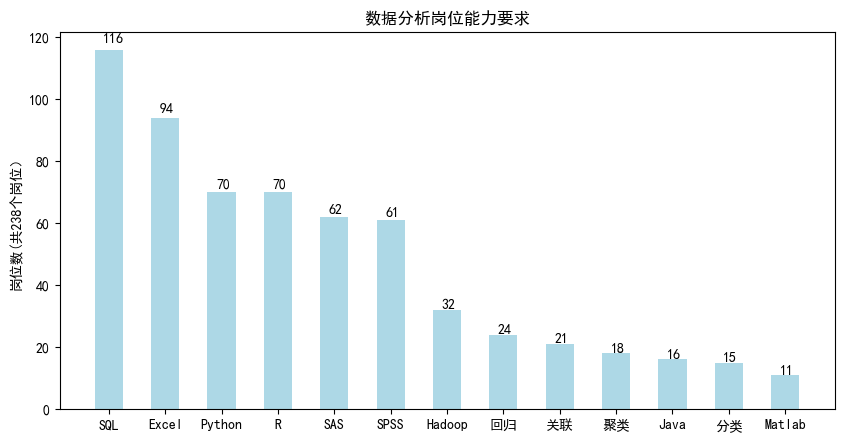

```python
plt.rcParams['font.sans-serif'] = ['simHei'] #设置字体，避免乱码
plt.rcParams['axes.unicode_minus'] = False
plt.figure(figsize=(10,5), dpi = 100) #设定图片宽度和精度
ax1=plt.subplot(111) #设定绘图范围
width=0.5 #设定条形宽度
x_bar=np.arange(13)
rect=ax1.bar(x=x_bar,height=SkillNum_sort,width=width,color="lightblue") #绘图
for rec in rect: #添加数据标签
    x=rec.get_x()
    height=rec.get_height()
    ax1.text(x+0.15,1.02*height,str(int(height)))

ax1.set_xticks(x_bar)
ax1.set_xticklabels(Labels_sort) #X轴坐标
ax1.set_ylabel("岗位数(共%d个岗位）" %(Job_num)) #y轴坐标
ax1.set_title('数据分析岗位能力要求') #标题
plt.show()
```

**由上图可见，“数据分析师”岗位较多要求的技能为`SQL`、`Excel`、`Python`和`R`。**

`2.4` 为了继续探索“数据分析师”岗位的特性和减少代码量，将`2.2`和`2.3`的代码改写为函数。

```python
def Sort_Skill(df):
    Job_num = len(df)
    df_skill = df.iloc[:,0:13] #删除年份和薪酬
    Label = list(df_skill.axes[1]) #提取标签
    SkillMat = np.array(df_skill) #并转换成矩阵
    SkillSum = SkillMat.sum(axis=0) #列方向相加
    SkillNum_sort = sorted(SkillSum, reverse=True) #从大到小排序
    Index_sort = np.argsort(-SkillSum) #获取排序后的标签顺序
    Labels_sort = [] #排序后的标签
    for i in range(13):
            Label_sort = Label[Index_sort[i]]
            Labels_sort.append(Label_sort) #排序后的标签
    return Job_num, SkillNum_sort, Labels_sort

def Draw_Skill(Job_num, SkillNum_sort, Labels_sort, Title):
    plt.rcParams['font.sans-serif'] = ['simHei']
    plt.rcParams['axes.unicode_minus'] = False
    plt.figure(figsize=(10,5), dpi = 100) #设定图片宽度和精度
    ax1=plt.subplot(111) #设定绘图范围
    width=0.5 #设定条形宽度
    x_bar=np.arange(13)
    rect=ax1.bar(x=x_bar,height=SkillNum_sort,width=width,color="lightblue") #绘图
    for rec in rect: #添加数据标签
        x=rec.get_x()
        height=rec.get_height()
        ax1.text(x+0.15,1.02*height,str(int(height)))

    ax1.set_xticks(x_bar)
    ax1.set_xticklabels(Labels_sort) #X轴坐标
    ax1.set_ylabel("岗位数(共%d个岗位）" %(Job_num)) #y轴坐标
    ax1.set_title(Title) #标题
    plt.show()
```

`2.5` 探索月薪1万以上的“数据分析师”岗位，对技能的要求

```python
df_1w = df.query('Sal_Avg >= 10000')
df_1w.head()
```

|  | Python | SQL | Hadoop | Excel | R | SPSS | SAS | Matlab | Java | 分类 | 聚类 | 关联 | 回归 | 1-3年 | 1年以下 | 3-5年 | 5-10年 | 不限 | Sal_Avg |
| --- | --- | --- | --- | --- | --- | --- | --- | --- | --- | --- | --- | --- | --- | --- | --- | --- | --- | --- | --- |
| 1 | 1 | 1 | 0 | 0 | 0 | 0 | 0 | 0 | 1 | 0 | 0 | 0 | 0 | 0 | 0 | 0 | 0 | 1 | 10000 |
| 4 | 0 | 0 | 0 | 0 | 0 | 0 | 0 | 0 | 0 | 0 | 0 | 0 | 0 | 0 | 0 | 1 | 0 | 0 | 15000 |
| 7 | 0 | 0 | 0 | 1 | 0 | 1 | 0 | 0 | 0 | 0 | 0 | 0 | 0 | 1 | 0 | 0 | 0 | 0 | 10000 |
| 8 | 0 | 0 | 0 | 0 | 0 | 0 | 0 | 0 | 0 | 0 | 0 | 0 | 0 | 1 | 0 | 0 | 0 | 0 | 16500 |
| 10 | 1 | 0 | 1 | 0 | 1 | 0 | 0 | 0 | 0 | 0 | 0 | 0 | 1 | 0 | 0 | 0 | 1 | 0 | 27500 |

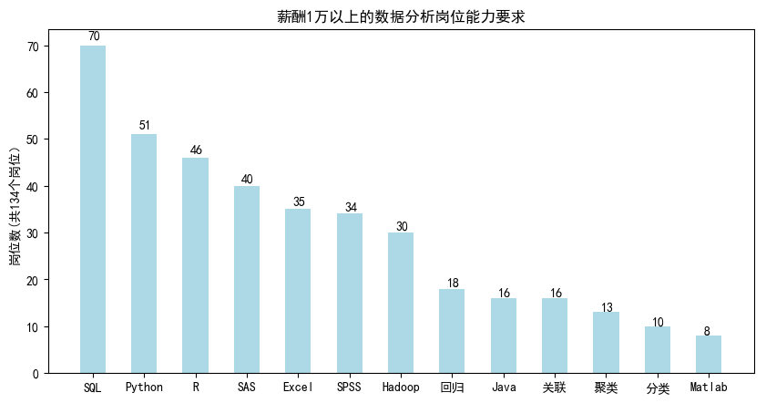

```python
Job_num_1w, SkillNum_sort_1w, Labels_sort_1w = Sort_Skill(df_1w)
Title_1w = '薪酬1万以上的数据分析岗位能力要求'
Draw_Skill(Job_num_1w, SkillNum_sort_1w, Labels_sort_1w, Title_1w)
```

**由上图可见，薪酬1万以上的“数据分析师”岗位较多要求的技能为`SQL`、`Python`和`R`，对`Excel`的需求有所减少。**

`2.6` 探索不同工作年限的“数据分析师”岗位，对技能的要求

```python
def Draw_Skill_Year(df, Year):
    df_year = df[df[Year] == 1]
    Job_year, SkillNum_year, Labels_year = Sort_Skill(df_year)
    Title_year = '工作经验{}的数据分析岗位能力要求'.format(Year)
    Draw_Skill(Job_year, SkillNum_year, Labels_year, Title_year)
```

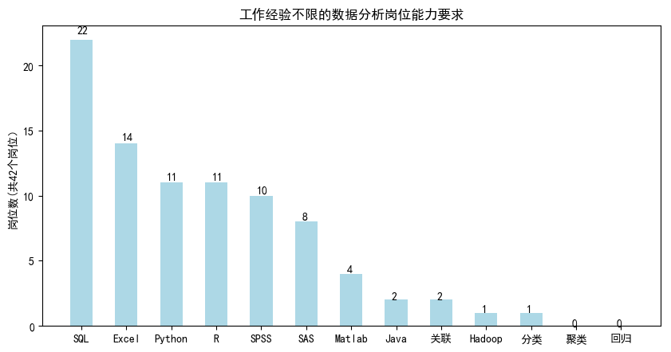

```python
Draw_Skill_Year(df, '不限')
```

**由上图可见，工作经验为`不限`的“数据分析师”岗位较多要求的技能为`SQL`、`Excel`、`Python`和`R`。**

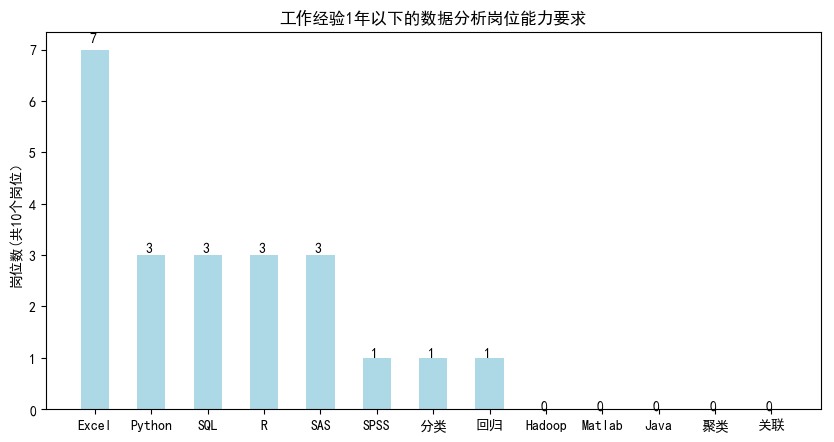

```python
Draw_Skill_Year(df, '1年以下')
```

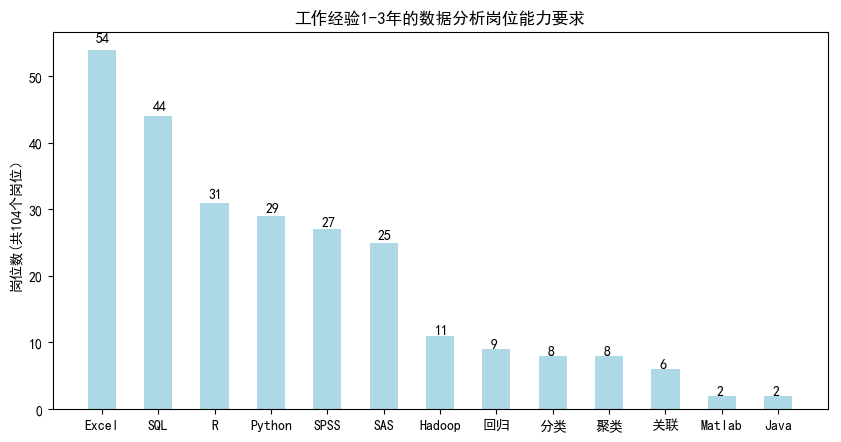

```python
Draw_Skill_Year(df, '1-3年')
```

**由上图可见，工作经验为`1-3年`的“数据分析师”岗位较多要求的技能为`Excel`、`SQL`和`R`，可见中级的岗位对`Excel`和`SQL`要求较多，同时也对`R`和`Python`有一定要求。**

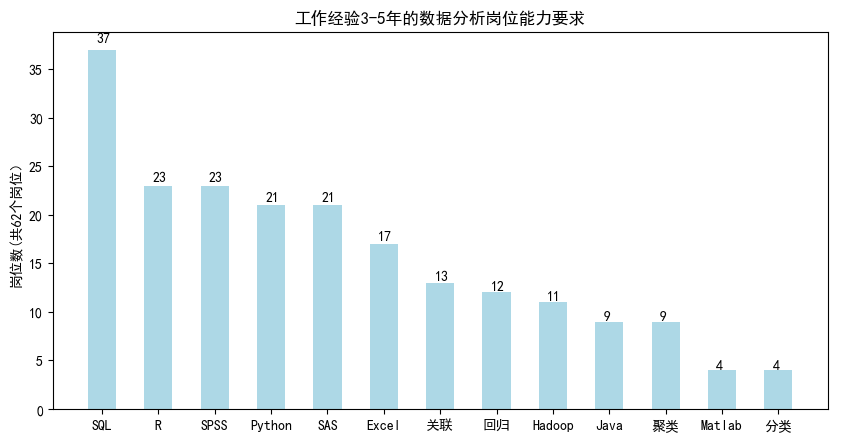

```python
Draw_Skill_Year(df, '3-5年')
```

**由上图可见，工作经验为`3-5年`的“数据分析师”岗位较多要求的技能为`SQL`、`R`、`SPSS`，可见中高级的岗位对`SQL`要求较多，也对编程语言（`R`和`Python`）和统计软件（`SPSS`和`SAS`）均有一定要求，但对`Excel`的需求减少了。**

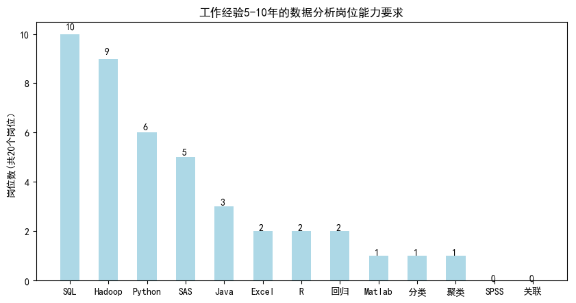

```python
Draw_Skill_Year(df, '5-10年')
```

**由上图可见，工作经验为`5-10年`的“数据分析师”岗位较多要求的技能为`SQL`、`Hadoop`、`Python`，可见高级的岗位依然对`SQL`要求较多，同时也对`Hadoop`的要求较多。**

**总结：**  
**1、通过对“数据分析师”岗位的分析，最需要掌握的工具为`SQL`，其次为编程语言`Python`和`R`，在数据分析师生涯的各个阶段都需要使用。**  
**2、“数据分析师”在初级阶段时还需要掌握使用`Excel`，中级时需要掌握统计学软件`SPSS`、`SAS`，高级时需要掌握`Hadoop`。**

### 3. 探索"掌握技能"和"工作年限"与"薪酬"的关系

`3.1` 以“掌握技能”和“工作年限”作为自变量，以“薪酬”为因变量，进行线性回归

`3.2` 新建自变量`df_log`，并添加截距

```python
df_log = df.iloc[:,0:13]
df_log = df_log.join(df.loc[:,['不限','1-3年','3-5年','5-10年']])
df_log['intercept'] = 1
df_log.head()
```

|  | Python | SQL | Hadoop | Excel | R | SPSS | SAS | Matlab | Java | 分类 | 聚类 | 关联 | 回归 | 不限 | 1-3年 | 3-5年 | 5-10年 | intercept |
| --- | --- | --- | --- | --- | --- | --- | --- | --- | --- | --- | --- | --- | --- | --- | --- | --- | --- | --- |
| 0 | 0 | 0 | 0 | 1 | 0 | 0 | 0 | 0 | 0 | 0 | 0 | 0 | 0 | 0 | 1 | 0 | 0 | 1 |
| 1 | 1 | 1 | 0 | 0 | 0 | 0 | 0 | 0 | 1 | 0 | 0 | 0 | 0 | 1 | 0 | 0 | 0 | 1 |
| 2 | 1 | 0 | 0 | 0 | 1 | 0 | 0 | 0 | 0 | 0 | 0 | 0 | 0 | 0 | 1 | 0 | 0 | 1 |
| 3 | 0 | 0 | 0 | 0 | 0 | 0 | 0 | 0 | 0 | 0 | 0 | 0 | 0 | 0 | 1 | 0 | 0 | 1 |
| 4 | 0 | 0 | 0 | 0 | 0 | 0 | 0 | 0 | 0 | 0 | 0 | 0 | 0 | 0 | 0 | 1 | 0 | 1 |

`3.3` 使用`statsmodels`进行线性回归

```python
lm = sm.OLS(df['Sal_Avg'],df_log)
results = lm.fit()
results.summary()
```

OLS Regression Results

| Dep. Variable: | Sal_Avg | R-squared: | 0.565 |
| --- | --- | --- | --- |
| Model: | OLS | Adj. R-squared: | 0.531 |
| Method: | Least Squares | F-statistic: | 16.79 |
| Date: | Fri, 04 May 2018 | Prob (F-statistic): | 5.11e-31 |
| Time: | 21:21:15 | Log-Likelihood: | -2371.9 |
| No. Observations: | 238 | AIC: | 4780. |
| Df Residuals: | 220 | BIC: | 4842. |
| Df Model: | 17 |  |  |
| Covariance Type: | nonrobust |  |  |

|  | coef | std err | t | P>\|t\| | [0.025 | 0.975] |
| --- | --- | --- | --- | --- | --- | --- |
| Python | -253.4662 | 1100.146 | -0.230 | 0.818 | -2421.640 | 1914.707 |
| SQL | 729.8247 | 808.611 | 0.903 | 0.368 | -863.790 | 2323.439 |
| Hadoop | 5063.4162 | 1144.365 | 4.425 | 0.000 | 2808.095 | 7318.737 |
| Excel | -1852.1406 | 828.086 | -2.237 | 0.026 | -3484.138 | -220.143 |
| R | 1909.4369 | 1181.726 | 1.616 | 0.108 | -419.515 | 4238.389 |
| SPSS | -1069.7854 | 996.276 | -1.074 | 0.284 | -3033.251 | 893.681 |
| SAS | -1424.1819 | 1002.819 | -1.420 | 0.157 | -3400.543 | 552.179 |
| Matlab | -1165.0231 | 1999.872 | -0.583 | 0.561 | -5106.382 | 2776.336 |
| Java | -2184.8886 | 1663.255 | -1.314 | 0.190 | -5462.841 | 1093.064 |
| 分类 | 1027.4172 | 1868.439 | 0.550 | 0.583 | -2654.912 | 4709.746 |
| 聚类 | -441.3313 | 2472.523 | -0.178 | 0.858 | -5314.193 | 4431.531 |
| 关联 | -63.1016 | 1599.143 | -0.039 | 0.969 | -3214.701 | 3088.498 |
| 回归 | 414.1393 | 1900.980 | 0.218 | 0.828 | -3332.323 | 4160.602 |
| 不限 | 2298.5603 | 1956.400 | 1.175 | 0.241 | -1557.125 | 6154.245 |
| 1-3年 | 3495.6526 | 1809.338 | 1.932 | 0.055 | -70.200 | 7061.505 |
| 3-5年 | 1.091e+04 | 1933.057 | 5.645 | 0.000 | 7102.402 | 1.47e+04 |
| 5-10年 | 1.71e+04 | 2195.157 | 7.791 | 0.000 | 1.28e+04 | 2.14e+04 |
| intercept | 6720.8373 | 1837.876 | 3.657 | 0.000 | 3098.741 | 1.03e+04 |

| Omnibus: | 58.277 | Durbin-Watson: | 2.157 |
| --- | --- | --- | --- |
| Prob(Omnibus): | 0.000 | Jarque-Bera (JB): | 120.388 |
| Skew: | 1.195 | Prob(JB): | 7.21e-27 |
| Kurtosis: | 5.535 | Cond. No. | 17.5 |

`3.4` 因变量选取`Hadoop`、`Excel`、`3-5年`、`5-10年`、`intercept`、`1-3年`，进行线性回归

```python
lm = sm.OLS(df['Sal_Avg'],df_log[['intercept','Hadoop','Excel','1-3年','3-5年','5-10年']])
results = lm.fit()
results.summary()
```

OLS Regression Results

| Dep. Variable: | Sal_Avg | R-squared: | 0.545 |
| --- | --- | --- | --- |
| Model: | OLS | Adj. R-squared: | 0.535 |
| Method: | Least Squares | F-statistic: | 55.51 |
| Date: | Fri, 04 May 2018 | Prob (F-statistic): | 8.91e-38 |
| Time: | 21:21:52 | Log-Likelihood: | -2377.3 |
| No. Observations: | 238 | AIC: | 4767. |
| Df Residuals: | 232 | BIC: | 4787. |
| Df Model: | 5 |  |  |
| Covariance Type: | nonrobust |  |  |

|  | coef | std err | t | P>\|t\| | [0.025 | 0.975] |
| --- | --- | --- | --- | --- | --- | --- |
| intercept | 8820.8341 | 801.446 | 11.006 | 0.000 | 7241.791 | 1.04e+04 |
| Hadoop | 4939.2274 | 1092.132 | 4.523 | 0.000 | 2787.464 | 7090.991 |
| Excel | -2101.0762 | 750.006 | -2.801 | 0.006 | -3578.770 | -623.382 |
| 1-3年 | 1738.0756 | 917.111 | 1.895 | 0.059 | -68.854 | 3545.006 |
| 3-5年 | 8757.9852 | 1019.681 | 8.589 | 0.000 | 6748.967 | 1.08e+04 |
| 5-10年 | 1.489e+04 | 1484.287 | 10.033 | 0.000 | 1.2e+04 | 1.78e+04 |

| Omnibus: | 68.052 | Durbin-Watson: | 2.110 |
| --- | --- | --- | --- |
| Prob(Omnibus): | 0.000 | Jarque-Bera (JB): | 167.245 |
| Skew: | 1.307 | Prob(JB): | 4.82e-37 |
| Kurtosis: | 6.168 | Cond. No. | 6.36 |

**根据多元线性回归的结果，1年以下经验的平均薪酬约为8820，随着工作年限的增加，薪酬也在增加；会使用`Hadoop`，所获得的薪酬明显较高，可以作为以后的学习路径；会使用`Excel`,薪酬会下降，显然违反客观规律，但也反映了中低级的岗位相对高级的岗位对Excel的需求更大**

```python
from sklearn.model_selection import train_test_split
from sklearn.linear_model import LinearRegression
```

```python
X_train,X_test,y_train,y_test = train_test_split(df[['Hadoop','Excel','1-3年','3-5年','5-10年']],df['Sal_Avg'],test_size=0.3)
```

```python
lm2 = LinearRegression()
lm2.fit(X_train, y_train)
lm2.score(X_test, y_test)
```

```
0.49075473164669325
```

```python
label = ['Hadoop','Excel','1-3年','3-5年','5-10年','intercept']
value = list(lm2.coef_)
value.append(lm2.intercept_)
```

```python
for each in zip(label,value):
    print(each)
```

```
('Hadoop', 4732.617671442322)
('Excel', -1995.25431642504)
('1-3年', 1742.4042370639281)
('3-5年', 8654.95708201242)
('5-10年', 15443.635576490147)
('intercept', 8829.667642694589)
```

**使用`sklearn`和`statsmedels`进行线性回归的结果基本一致**